# GSEA Simulation report

```r
#project_dir <- snakemake@config$project_dir
project_dir <-  '/project2/mstephens/ktayeb/logistic-susie-snakemake'
knitr::opts_knit$set(root.dir = project_dir)
```

```r
library(ggcorrplot)
library(dplyr)
library(reticulate)
library(tidyr)
library(tictoc)
library(ggplot2)

source('workflow/scripts/plotting/plot_functions.R')

# httpgd::hgd()

load_tbl <- function(path){
    print(path)
    dplyr::as_tibble(readRDS(path))
}
pip_summary_files <- Sys.glob('results/gsea/*/*_pip_summary.rds')
res_pip <- purrr::map_dfr(pip_summary_files, ~load_tbl(.x))
```

```
## [1] "results/gsea/X_bin_med/gibss_abf_default_pip_summary.rds"
## [1] "results/gsea/X_bin_med/gibss_abf_L1_pip_summary.rds"
## [1] "results/gsea/X_bin_med/gibss_labf_default_pip_summary.rds"
## [1] "results/gsea/X_bin_med/gibss_labf_L1_pip_summary.rds"
## [1] "results/gsea/X_bin_med/linear_susie_default_pip_summary.rds"
## [1] "results/gsea/X_bin_med/linear_susie_L1_pip_summary.rds"
## [1] "results/gsea/X_bin_strong/gibss_abf_default_pip_summary.rds"
## [1] "results/gsea/X_bin_strong/gibss_abf_L1_pip_summary.rds"
## [1] "results/gsea/X_bin_strong/gibss_labf_default_pip_summary.rds"
## [1] "results/gsea/X_bin_strong/gibss_labf_L1_pip_summary.rds"
## [1] "results/gsea/X_bin_strong/linear_susie_default_pip_summary.rds"
## [1] "results/gsea/X_bin_strong/linear_susie_L1_pip_summary.rds"
## [1] "results/gsea/X_bin_weak/gibss_abf_default_pip_summary.rds"
## [1] "results/gsea/X_bin_weak/gibss_abf_L1_pip_summary.rds"
## [1] "results/gsea/X_bin_weak/gibss_labf_default_pip_summary.rds"
## [1] "results/gsea/X_bin_weak/gibss_labf_L1_pip_summary.rds"
## [1] "results/gsea/X_bin_weak/linear_susie_default_pip_summary.rds"
## [1] "results/gsea/X_bin_weak/linear_susie_L1_pip_summary.rds"
```

```r
cs_summary_files <- Sys.glob('results/gsea/*/*_cs_summary.rds')
res_cs <- purrr::map_dfr(cs_summary_files, ~dplyr::as_tibble(readRDS(.x)))

manifest <- readr::read_delim('config/gsea_sim/gsea_sim_manifest.tsv', delim='\t')
threshold_var <- function(df, var, val, comp){
#   var <- as_string(ensym(var))
  filter(df, comp(.data[[var]], !!val))
}

cs_filtered_coverage <- function(res_cs, var, val, comp){
    # counts number of causal variables
    Q_tbl <- res_cs %>%
        select(c(method, sim_id, q)) %>%
        unique() %>%
        group_by(method) %>%
        summarize(Q = sum(q))

    # coverage, and frequency of number of causal variants per CS
    res_cs %>%
        left_join(Q_tbl) %>%
        threshold_var(var, val, comp) %>%
        mutate(val = val) %>%
        group_by(method) %>%
        summarize(coverage = mean(covered), n_found2 = list(table(n_found)), mean_size = mean(size), val = val[1], Q=Q[1], n_found = sum(n_found)) %>%
        unnest_wider(n_found2)
}

make_plot <- function(res_cs, var, vals, op){
    # filter CSs based on `val` and `op`
    f <- function(val){
        res_cs %>%
            cs_filtered_coverage(var, val, op)
    }
    # compute coverage at each `val` in `vals`
    filtered_coverage <- purrr::map_dfr(vals, f)

    # plot coverage as a function of val
    a <- filtered_coverage %>%
        ggplot(aes(x = val, y = coverage, color = method)) +
        geom_path() +
        geom_hline(yintercept = 0.95) +
        xlab(var)

    # plot power as a function of val
    b <- filtered_coverage %>%
        mutate(power = n_found/Q) %>%
        mutate(power = `1`/Q) %>%
        ggplot(aes(x = val, y = power, color = method)) +
        geom_path() +
        xlab(var)

    cowplot::plot_grid(a, b)
}
```

## Weak LD Structure

### LD Matrix

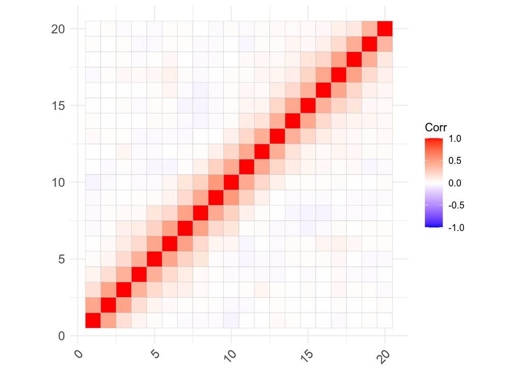

```r
R_weak <- readRDS('results/gsea/X_bin_weak/ld.rds')
ggcorrplot(R_weak[1:20, 1:20])
```

### Simulation settings

```r
# show unique simulation settings for SER simulations
manifest %>%
    dplyr::filter(X == 'X_bin_weak') %>%
    select(c(X, beta0, beta)) %>%
    unique() %>%
    rmarkdown::paged_table()
```

| X | beta0 | beta |
| --- | --- | --- |
| X_bin_weak | -5 | 0.5 |
| X_bin_weak | -5 | 1.0 |
| X_bin_weak | -5 | 2.0 |
| X_bin_weak | -5 | 4.0 |
| X_bin_weak | -4 | 0.5 |
| X_bin_weak | -4 | 1.0 |
| X_bin_weak | -4 | 2.0 |
| X_bin_weak | -4 | 4.0 |
| X_bin_weak | -3 | 0.5 |
| X_bin_weak | -3 | 1.0 |

[output cut: 6 more lines]

### Credible sets

#### CS size distribution

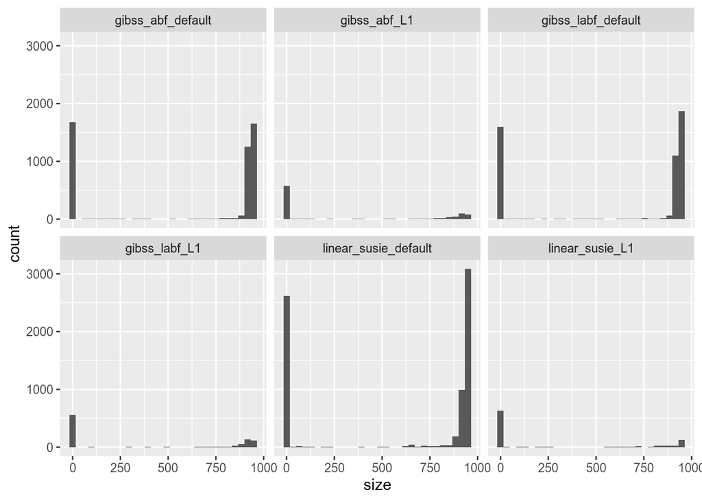

```r
# histogram of CSs, and coverage over all simulations
res_cs %>%
    dplyr::filter(X == 'X_bin_weak') %>%
    ggplot(aes(x = size)) +
    geom_histogram() +
    facet_wrap(vars(method))
```

#### CS coverage

```r
res_cs %>%
    dplyr::filter(X == 'X_bin_weak') %>%
    group_by(method) %>%
    summarize(coverage = mean(covered), n_found = list(table(n_found)), mean_size = mean(size)) %>%
    unnest_wider(n_found) %>%
    knitr::kable()
```

| method | coverage | 0 | 1 | 2 | 3 | 4 | 5 | mean_size |
| --- | --- | --- | --- | --- | --- | --- | --- | --- |
| gibss_abf_L1 | 0.9916667 | 8 | 560 | 128 | 142 | 34 | 88 | 314.1979 |
| gibss_abf_default | 0.8183333 | 872 | 2564 | 164 | 620 | 132 | 448 | 594.8425 |
| gibss_labf_L1 | 0.9770833 | 22 | 576 | 120 | 132 | 12 | 98 | 358.8750 |
| gibss_labf_default | 0.8745833 | 602 | 2766 | 236 | 632 | 90 | 474 | 608.7517 |
| linear_susie_L1 | 0.9541667 | 44 | 614 | 114 | 106 | 18 | 64 | 266.6083 |
| linear_susie_default | 0.9125000 | 630 | 4290 | 180 | 1185 | 189 | 726 | 581.4021 |

```r
res_cs %>%
    dplyr::filter(X == 'X_bin_weak') %>%
    filter(size < 200) %>%
    group_by(method) %>%
    summarize(coverage = mean(covered), n_found = list(table(n_found)), mean_size = mean(size)) %>%
    unnest_wider(n_found) %>%
    knitr::kable()
```

| method | coverage | 0 | 1 | 2 | 3 | 4 | 5 | mean_size |
| --- | --- | --- | --- | --- | --- | --- | --- | --- |
| gibss_abf_L1 | 0.9933555 | 4 | 412 | 114 | 42 | 18 | 12 | 4.750831 |
| gibss_abf_default | 0.9952996 | 8 | 1656 | 26 | 6 | 4 | 2 | 2.882491 |
| gibss_labf_L1 | 1.0000000 | NA | 428 | 104 | 32 | NA | NA | 2.567376 |
| gibss_labf_default | 0.9987700 | 2 | 1594 | 24 | 4 | 2 | NA | 2.998770 |
| linear_susie_L1 | 0.9541284 | 30 | 498 | 98 | 24 | 4 | NA | 3.856269 |
| linear_susie_default | 0.9741282 | 69 | 2535 | 48 | 9 | 6 | NA | 2.415073 |

#### Conditional coverage

```
## Defaulting to continuous.
```

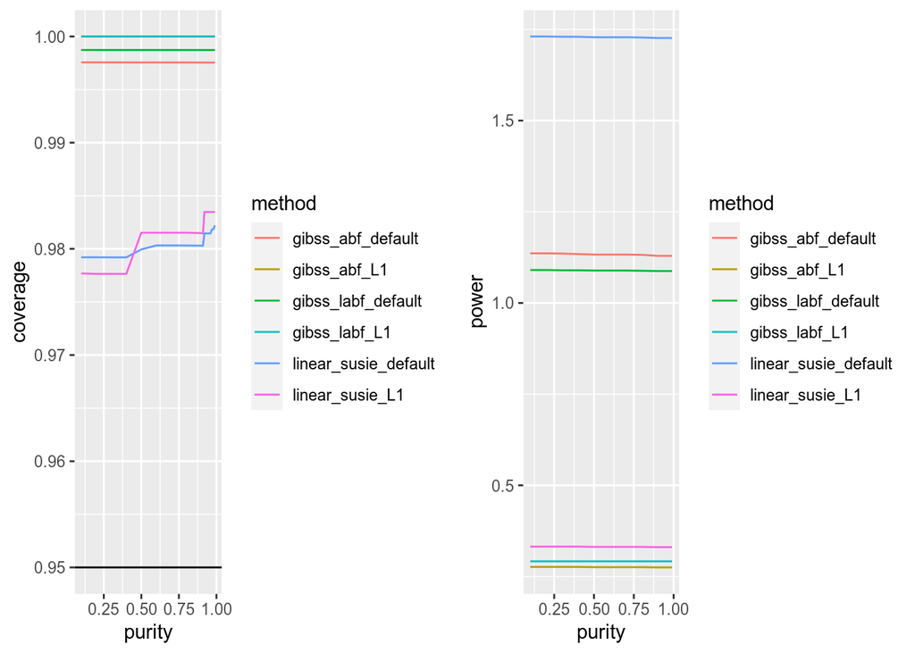

```r
# filter on purity
vals <- c(seq(0.1, 0.9, by = 0.1), seq(0.91, .99, by = 0.01))
res_cs %>%
    dplyr::filter(X == 'X_bin_weak') %>%
    make_plot('purity', vals, `>`)
```

```
## Defaulting to continuous.
```

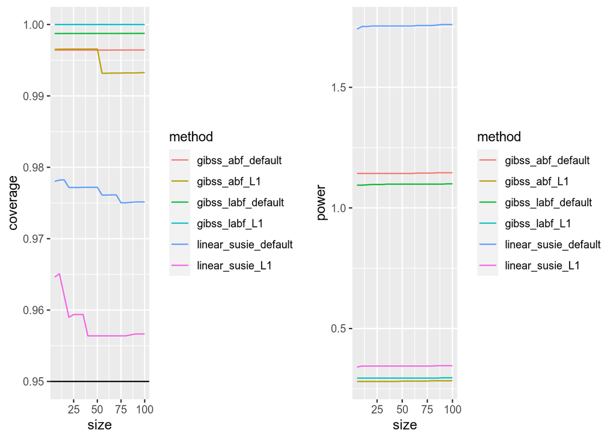

```r
# filter on cs size
vals <- seq(5, 100, by=5)
res_cs %>%
    dplyr::filter(X == 'X_bin_weak') %>%
    make_plot('size', vals, `<`)
```

```
## Defaulting to continuous.
```

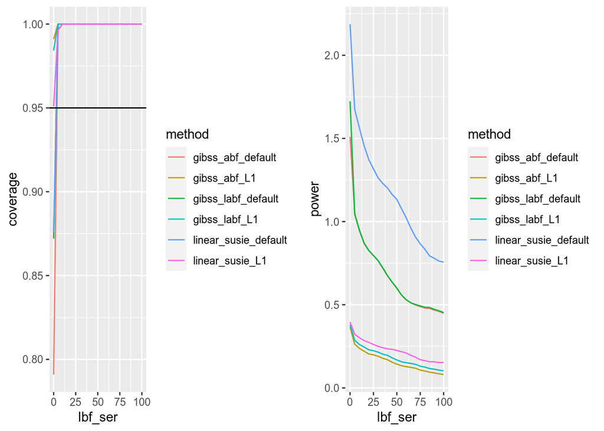

```r
# filter on the SER-level BFs
# note multiple CSs may capture the same effect causing "power" > 1
vals <- seq(0, 100, by=5)
res_cs %>%
    dplyr::filter(X == 'X_bin_weak') %>%
    make_plot('lbf_ser', vals, `>`)
```

### Power vs FDP (PIP ordering)

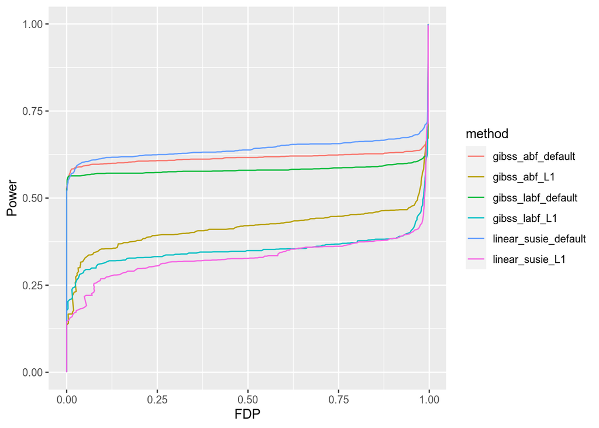

```r
# fdp vs power
fdp_plot <- res_pip %>%
    dplyr::filter(X == 'X_bin_weak') %>%
    unnest_longer(c(pip, causal)) %>%
    ggplot(aes(pip, causal, color=method)) +
    stat_fdp_power(geom='path', max_fdp=1.0) +
    labs(x = 'FDP', y = 'Power')
fdp_plot
```

### PIP Calibration

PIP calibration looks a little messy– may need more simulations to get a clear picture. Note that for the logistic SERs the only source of error here is the approximation error of using the Laplace ABF vs Wakefield ABF. TODO: add comparison to exact computation of the BF via quadrature.

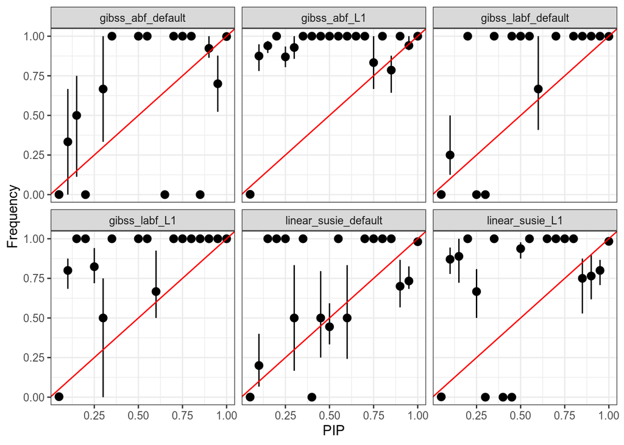

```r
pip_calibration_plot <- res_pip %>%
    dplyr::filter(X == 'X_bin_weak') %>%
    unnest_longer(c(pip, causal)) %>%
    ggplot(aes(pip, causal)) +
    stat_pip_calibration() +
    geom_abline(intercept = 0, slope = 1, color='red') +
    theme_bw() +
    labs(x='PIP', y='Frequency') +
    facet_wrap(vars(method))
pip_calibration_plot
```

## med LD Structure

### LD Matrix

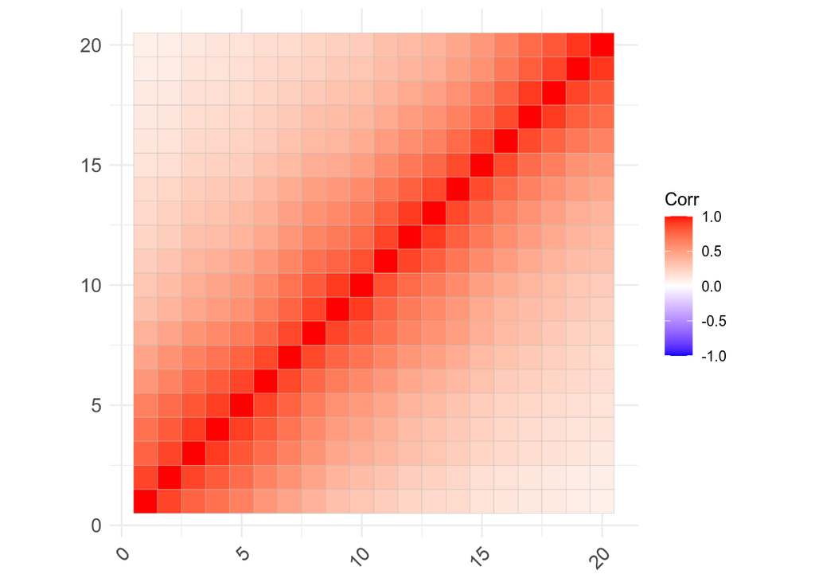

```r
R_med <- readRDS('results/gsea/X_bin_med/ld.rds')
ggcorrplot(R_med[1:20, 1:20])
```

### Simulation settings

```r
# show unique simulation settings for SER simulations
manifest %>%
    dplyr::filter(X == 'X_bin_med') %>%
    select(c(X, beta0, beta)) %>%
    unique() %>%
    rmarkdown::paged_table()
```

| X | beta0 | beta |
| --- | --- | --- |
| X_bin_med | -5 | 0.5 |
| X_bin_med | -5 | 1.0 |
| X_bin_med | -5 | 2.0 |
| X_bin_med | -5 | 4.0 |
| X_bin_med | -4 | 0.5 |
| X_bin_med | -4 | 1.0 |
| X_bin_med | -4 | 2.0 |
| X_bin_med | -4 | 4.0 |
| X_bin_med | -3 | 0.5 |
| X_bin_med | -3 | 1.0 |

[output cut: 6 more lines]

### Credible sets

#### CS size distribution

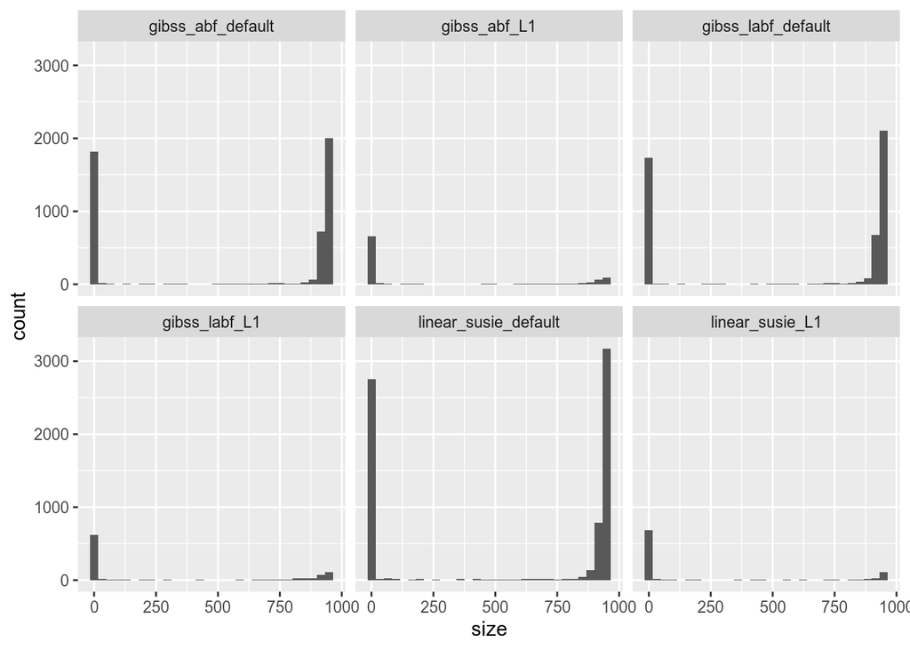

```r
# histogram of CSs, and coverage over all simulations
res_cs %>%
    dplyr::filter(X == 'X_bin_med') %>%
    ggplot(aes(x = size)) +
    geom_histogram() +
    facet_wrap(vars(method))
```

#### CS coverage

```r
res_cs %>%
    dplyr::filter(X == 'X_bin_med') %>%
    group_by(method) %>%
    summarize(coverage = mean(covered), n_found = list(table(n_found)), mean_size = mean(size)) %>%
    unnest_wider(n_found) %>%
    knitr::kable()
```

| method | coverage | 0 | 1 | 2 | 3 | 4 | 5 | mean_size |
| --- | --- | --- | --- | --- | --- | --- | --- | --- |
| gibss_abf_L1 | 0.9666667 | 32 | 582 | 150 | 108 | 32 | 56 | 238.2375 |
| gibss_abf_default | 0.7991667 | 964 | 2582 | 160 | 566 | 116 | 412 | 567.9088 |
| gibss_labf_L1 | 0.9666667 | 32 | 602 | 132 | 110 | 18 | 66 | 273.4937 |
| gibss_labf_default | 0.8862500 | 546 | 2798 | 212 | 726 | 118 | 400 | 582.4000 |
| linear_susie_L1 | 0.9541667 | 44 | 670 | 114 | 74 | 20 | 38 | 212.1542 |
| linear_susie_default | 0.9029167 | 699 | 4299 | 198 | 1194 | 129 | 681 | 560.0508 |

```r
res_cs %>%
    dplyr::filter(X == 'X_bin_med') %>%
    filter(size < 200) %>%
    group_by(method) %>%
    summarize(coverage = mean(covered), n_found = list(table(n_found)), mean_size = mean(size)) %>%
    unnest_wider(n_found) %>%
    knitr::kable()
```

| method | coverage | 0 | 1 | 2 | 3 | 4 | 5 | mean_size |
| --- | --- | --- | --- | --- | --- | --- | --- | --- |
| gibss_abf_L1 | 0.9593023 | 28 | 466 | 138 | 34 | 20 | 2 | 5.566860 |
| gibss_abf_default | 0.9534128 | 86 | 1726 | 26 | 8 | NA | NA | 2.669556 |
| gibss_labf_L1 | 0.9785276 | 14 | 494 | 122 | 14 | 4 | 4 | 5.751534 |
| gibss_labf_default | 0.9886621 | 20 | 1704 | 32 | 4 | 2 | 2 | 2.581633 |
| linear_susie_L1 | 0.9444444 | 40 | 562 | 98 | 18 | 2 | NA | 5.755556 |
| linear_susie_default | 0.9671958 | 93 | 2667 | 45 | 18 | 12 | NA | 3.947090 |

#### Conditional coverage

```
## Defaulting to continuous.
```

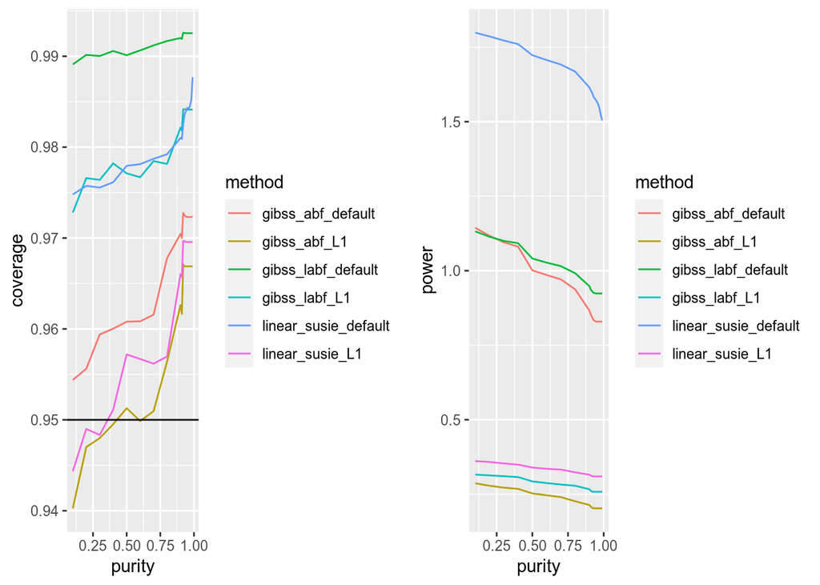

```r
# filter on purity
vals <- c(seq(0.1, 0.9, by = 0.1), seq(0.91, .99, by = 0.01))
res_cs %>%
    dplyr::filter(X == 'X_bin_med') %>%
    make_plot('purity', vals, `>`)
```

```
## Defaulting to continuous.
```

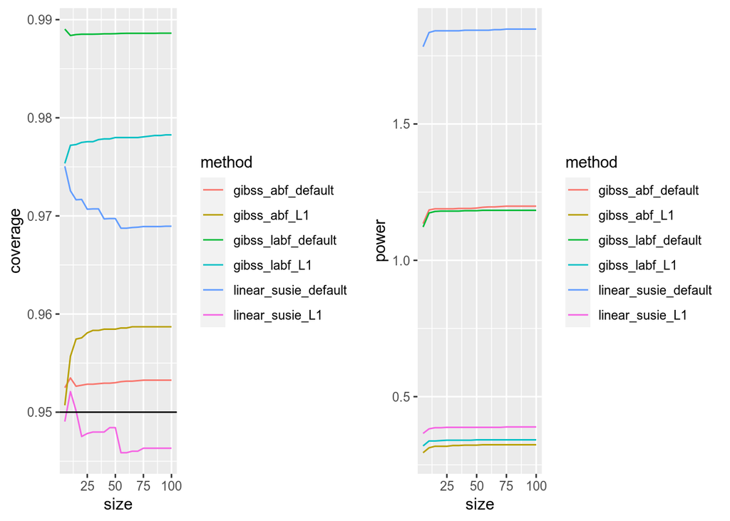

```r
# filter on cs size
vals <- seq(5, 100, by=5)
res_cs %>%
    dplyr::filter(X == 'X_bin_med') %>%
    make_plot('size', vals, `<`)
```

```
## Defaulting to continuous.
```

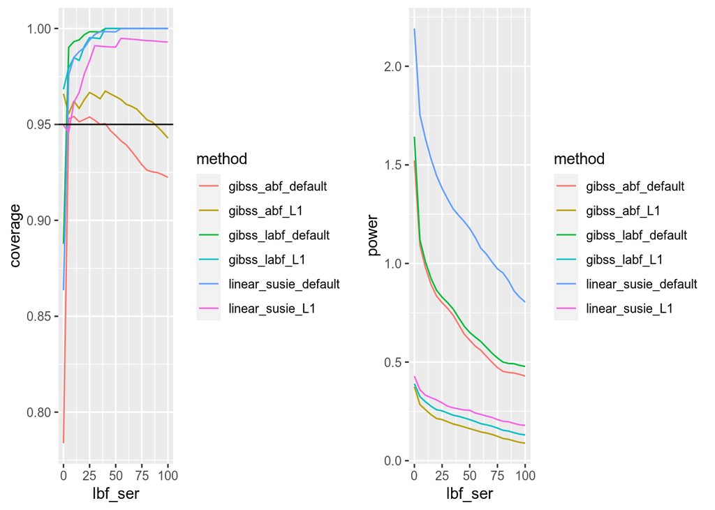

```r
# filter on the SER-level BFs
# note multiple CSs may capture the same effect causing "power" > 1
vals <- seq(0, 100, by=5)
res_cs %>%
    dplyr::filter(X == 'X_bin_med') %>%
    make_plot('lbf_ser', vals, `>`)
```

### Power vs FDP (PIP ordering)

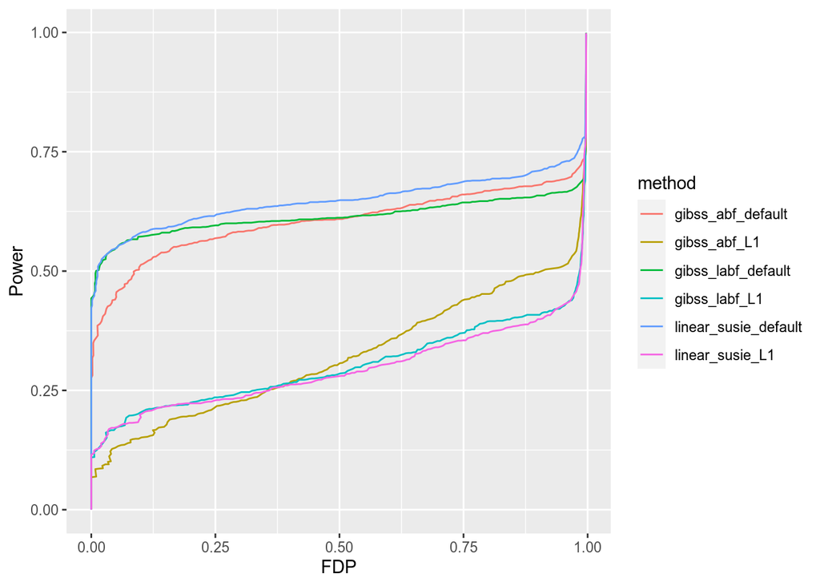

```r
# fdp vs power
fdp_plot <- res_pip %>%
    dplyr::filter(X == 'X_bin_med') %>%
    unnest_longer(c(pip, causal)) %>%
    ggplot(aes(pip, causal, color=method)) +
    stat_fdp_power(geom='path', max_fdp=1.0) +
    labs(x = 'FDP', y = 'Power')
fdp_plot
```

### PIP Calibration

PIP calibration looks a little messy– may need more simulations to get a clear picture. Note that for the logistic SERs the only source of error here is the approximation error of using the Laplace ABF vs Wakefield ABF. TODO: add comparison to exact computation of the BF via quadrature.

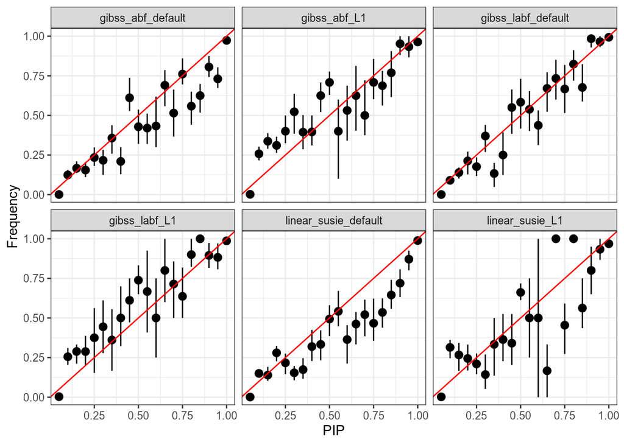

```r
pip_calibration_plot <- res_pip %>%
    dplyr::filter(X == 'X_bin_med') %>%
    unnest_longer(c(pip, causal)) %>%
    ggplot(aes(pip, causal)) +
    stat_pip_calibration() +
    geom_abline(intercept = 0, slope = 1, color='red') +
    theme_bw() +
    labs(x='PIP', y='Frequency') +
    facet_wrap(vars(method))
pip_calibration_plot
```

## Strong LD Structure

### LD Matrix

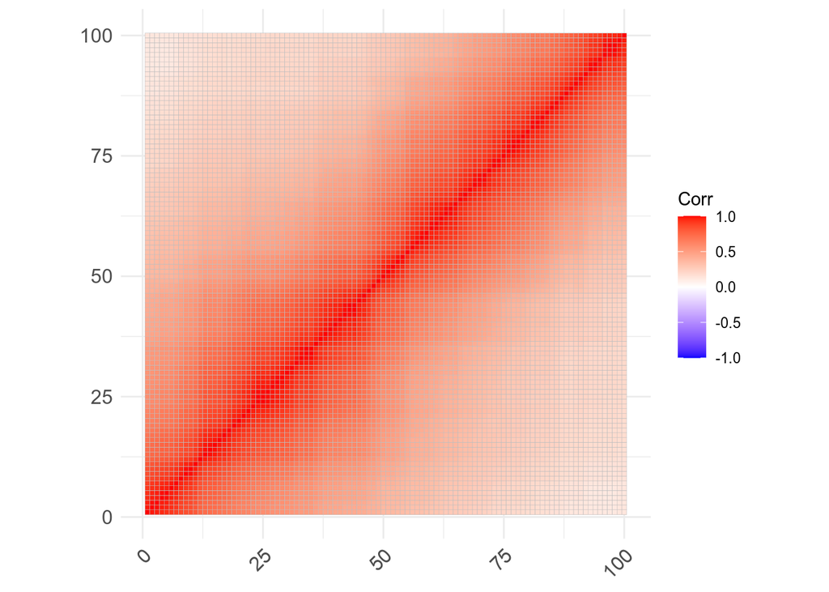

```r
R_strong <- readRDS('results/gsea/X_bin_strong/ld.rds')
ggcorrplot(R_strong[1:100, 1:100])
```

### Simulation settings

```r
# show unique simulation settings for SER simulations
manifest %>%
    dplyr::filter(X == 'X_bin_strong') %>%
    select(c(X, beta0, beta)) %>%
    unique() %>%
    rmarkdown::paged_table()
```

| X | beta0 | beta |
| --- | --- | --- |
| X_bin_strong | -5 | 0.5 |
| X_bin_strong | -5 | 1.0 |
| X_bin_strong | -5 | 2.0 |
| X_bin_strong | -5 | 4.0 |
| X_bin_strong | -4 | 0.5 |
| X_bin_strong | -4 | 1.0 |
| X_bin_strong | -4 | 2.0 |
| X_bin_strong | -4 | 4.0 |
| X_bin_strong | -3 | 0.5 |
| X_bin_strong | -3 | 1.0 |

[output cut: 6 more lines]

### Credible sets

#### CS size distribution

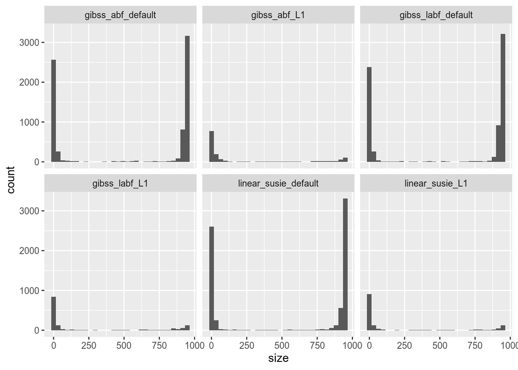

```r
# histogram of CSs, and coverage over all simulations
res_cs %>%
    filter(X == 'X_bin_strong') %>%
    ggplot(aes(x = size)) +
    geom_histogram() +
    facet_wrap(vars(method))
```

#### CS coverage

```r
res_cs %>%
    dplyr::filter(X == 'X_bin_strong') %>%
    group_by(method) %>%
    summarize(coverage = mean(covered), n_found = list(table(n_found)), mean_size = mean(size)) %>%
    unnest_wider(n_found) %>%
    knitr::kable()
```

| method | coverage | 0 | 1 | 2 | 3 | 4 | 5 | mean_size |
| --- | --- | --- | --- | --- | --- | --- | --- | --- |
| gibss_abf_L1 | 0.9041667 | 138 | 879 | 210 | 144 | 24 | 45 | 202.3250 |
| gibss_abf_default | 0.8295833 | 1227 | 4053 | 372 | 837 | 162 | 549 | 554.0187 |
| gibss_labf_L1 | 0.9312500 | 99 | 969 | 156 | 135 | 24 | 57 | 232.3063 |
| gibss_labf_default | 0.9362500 | 459 | 4443 | 402 | 1137 | 213 | 546 | 575.1846 |
| linear_susie_L1 | 0.8750000 | 180 | 981 | 117 | 96 | 30 | 36 | 188.8500 |
| linear_susie_default | 0.9191667 | 582 | 4464 | 249 | 1167 | 162 | 576 | 550.1612 |

```r
res_cs %>%
    dplyr::filter(X == 'X_bin_strong') %>%
    filter(size < 200) %>%
    group_by(method) %>%
    summarize(coverage = mean(covered), n_found = list(table(n_found)), mean_size = mean(size)) %>%
    unnest_wider(n_found) %>%
    knitr::kable()
```

| method | coverage | 0 | 1 | 2 | 3 | 4 | 5 | mean_size |
| --- | --- | --- | --- | --- | --- | --- | --- | --- |
| gibss_abf_L1 | 0.8805556 | 129 | 708 | 189 | 48 | 3 | 3 | 18.255556 |
| gibss_abf_default | 0.8970134 | 300 | 2505 | 81 | 24 | 3 | NA | 10.173018 |
| gibss_labf_L1 | 0.9190751 | 84 | 783 | 138 | 30 | 3 | NA | 14.283237 |
| gibss_labf_default | 0.9646409 | 96 | 2535 | 78 | 6 | NA | NA | 8.215470 |
| linear_susie_L1 | 0.8463612 | 171 | 816 | 102 | 15 | 9 | NA | 12.765499 |
| linear_susie_default | 0.8970438 | 303 | 2571 | 57 | 12 | NA | NA | 8.835882 |

#### Conditional coverage

```
## Defaulting to continuous.
```

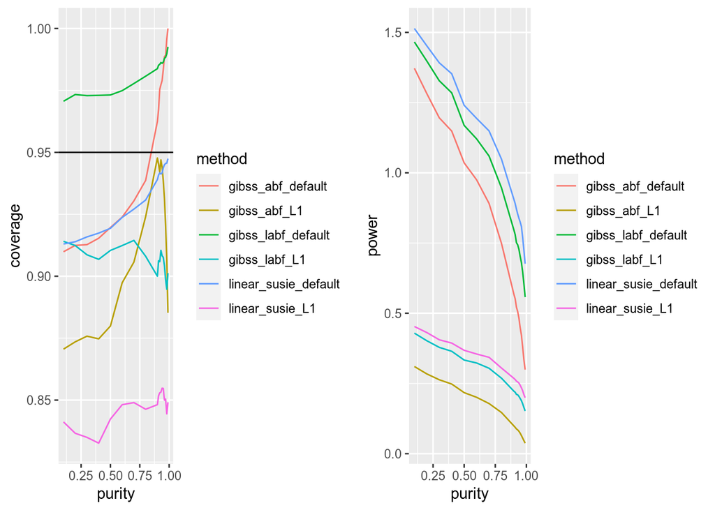

```r
# filter on purity
vals <- c(seq(0.1, 0.9, by = 0.1), seq(0.91, .99, by = 0.01))
res_cs %>%
    dplyr::filter(X == 'X_bin_strong') %>%
    make_plot('purity', vals, `>`)
```

```
## Defaulting to continuous.
```

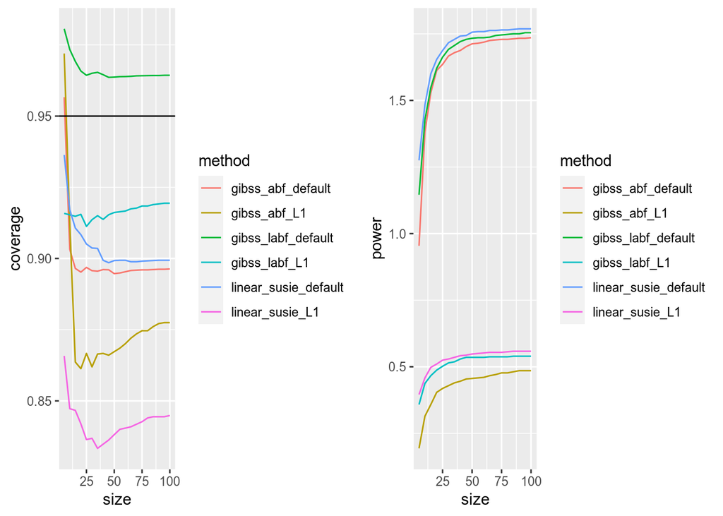

```r
# filter on cs size
vals <- seq(5, 100, by=5)
res_cs %>%
    dplyr::filter(X == 'X_bin_strong') %>%
    make_plot('size', vals, `<`)
```

```
## Defaulting to continuous.
```

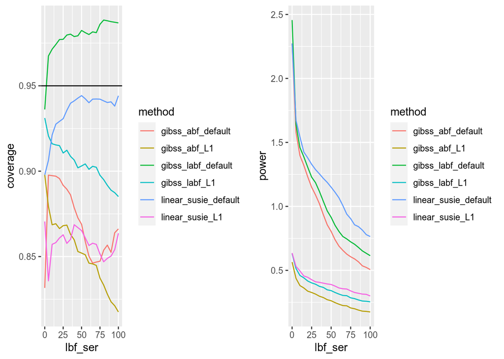

```r
# filter on the SER-level BFs
# note multiple CSs may capture the same effect causing "power" > 1
vals <- seq(0, 100, by=5)
res_cs %>%
    dplyr::filter(X == 'X_bin_strong') %>%
    make_plot('lbf_ser', vals, `>`)
```

### Power vs FDP (PIP ordering)

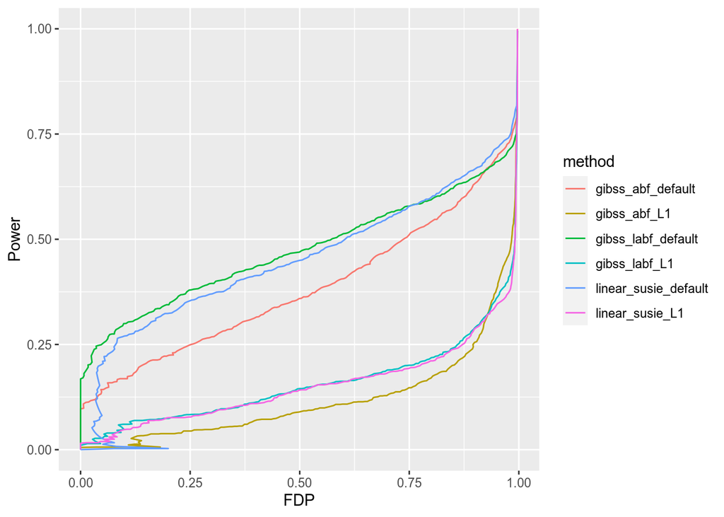

```r
# fdp vs power
fdp_plot <- res_pip %>%
    dplyr::filter(X == 'X_bin_strong') %>%
    unnest_longer(c(pip, causal)) %>%
    ggplot(aes(pip, causal, color=method)) +
    stat_fdp_power(geom='path', max_fdp=1.0) +
    labs(x = 'FDP', y = 'Power')
fdp_plot
```

### PIP Calibration

PIP calibration looks a little messy– may need more simulations to get a clear picture. Note that for the logistic SERs the only source of error here is the approximation error of using the Laplace ABF vs Wakefield ABF. TODO: add comparison to exact computation of the BF via quadrature.

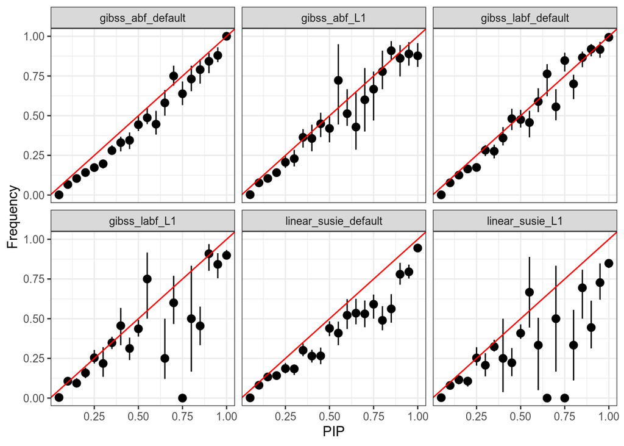

```r
pip_calibration_plot <- res_pip %>%
    dplyr::filter(X == 'X_bin_strong') %>%
    unnest_longer(c(pip, causal)) %>%
    ggplot(aes(pip, causal)) +
    stat_pip_calibration() +
    geom_abline(intercept = 0, slope = 1, color='red') +
    theme_bw() +
    labs(x='PIP', y='Frequency') +
    facet_wrap(vars(method))
pip_calibration_plot
```